# f_table()

## Introduction

After getting a vector of response events sorted by bins from a raw time vector, it is often necessary to create frequency tables in order to analyze the response distribution for a given experimental trial or session. Here we introduce a function to do so. The function takes a vector of ‘binarized’ responses as input and outputs a data frame with 3 columns:

- `bins` which is the bin index for every data point.
- `freq` the frequency of each bin.
- `prop` the frequency expressed as a proportion of the total responses.

This function includes zero-frequency bins in the given interval.

## Example

First let’s load a data sample of response times:

```r
data("r_times")

r_times
```

```
##   [1]  28.1  40.7  44.2  44.4  44.7  45.0  45.4  47.9  48.1  48.3  48.6  48.8
##  [13]  49.8  50.2  50.7  51.2  51.4  51.7  51.9  52.7  53.0  53.5  53.7  53.9
##  [25]  54.1  54.3  54.9  55.3  55.5  55.7  55.8  57.2  57.4  57.7  58.3  58.5
##  [37]  58.7  60.4  60.6  60.7  61.1  61.6  61.8  62.6  62.8  63.1  63.3  63.5
##  [49]  63.8  64.4  64.8  64.9  65.1  66.1  66.4  67.0  68.7  68.9  69.5  69.6
##  [61]  70.1  70.9  71.0  71.3  71.6  71.8  73.9  74.1  74.4  74.6  75.2  76.4
##  [73]  76.6  77.4  77.6  77.8  78.2  79.3  79.9  80.5  80.7  81.3  82.2  82.4
##  [85]  82.6  82.9  83.0  83.1  83.7  84.4  84.4  84.8  85.0  85.6  86.6  87.0
##  [97]  87.1  87.3  87.4  87.8  88.1  88.2  89.4  99.1  99.3  99.6  99.8 100.2
## [109] 133.1 133.1 133.6 134.9 135.2 135.3 135.4 135.7 136.5 173.8 174.1 174.3
## [121] 174.7 175.9 176.3 176.6 177.4 177.5 177.7 178.1 178.2 178.4 178.5 178.8
## [133] 179.4
```

Now we will use the `get_bins()` function included in this package (see `get_bins.Rmd` for further details) to convert the raw data points into time bins and then create the frequency table with `f_table`:

```r
bin_res <- 10 # Lower values will create a higher resolution distribution and vice-versa.
min_x <- 0 # We use 0 as a starting point in order to get a distribution for the complete duration of the trail.
max_x <- 180 # In this specific example the total trail duration was 3 minutes.
binarized_data <- get_bins(r_times, min_x, max_x, bin_res)
data_ftable <- f_table(binarized_data, min_x, max_x, bin_res)

data_ftable
```

```
##    bins freq        prop
## 1     0    0 0.000000000
## 2    10    0 0.000000000
## 3    20    0 0.000000000
## 4    30    1 0.007518797
## 5    40    0 0.000000000
## 6    50   12 0.090225564
## 7    60   24 0.180451128
## 8    70   23 0.172932331
## 9    80   19 0.142857143
## 10   90   24 0.180451128
## 11  100    4 0.030075188
## 12  110    1 0.007518797
## 13  120    0 0.000000000
## 14  130    0 0.000000000
## 15  140    9 0.067669173
## 16  150    0 0.000000000
## 17  160    0 0.000000000
## 18  170    0 0.000000000
## 19  180   16 0.120300752
```

Finally let’s plot the data to visualize the resulting structure:

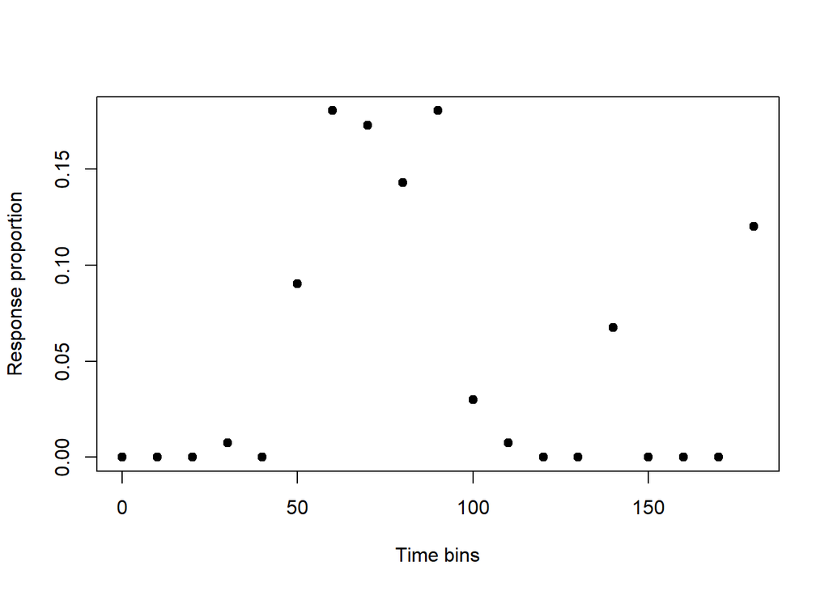